# Анализ продаж видеоигр на конкурирующих платформах

Павел Ермаков

## Введение

Данные для исследования взяты из списка наиболее популярных в настоящее время массивов данных на платформе [Kaggle](https://www.kaggle.com)[^1].

Массив данных содержит сведения о 16598 видеоиграх, чьи мировые объемы продаж превысили 100 тысяч копий. Сведения собраны за период с 1980 г. по настоящее время и включают в себя следующие интересующие нас переменные:

- Номинативная переменная **Platform** (игровая платформа) со следующими значениями:

```
##  [1] "2600" "3DO"  "3DS"  "DC"   "DS"   "GB"   "GBA"  "GC"   "GEN"  "GG"
## [11] "N64"  "NES"  "NG"   "PC"   "PCFX" "PS"   "PS2"  "PS3"  "PS4"  "PSP"
## [21] "PSV"  "SAT"  "SCD"  "SNES" "TG16" "Wii"  "WiiU" "WS"   "X360" "XB"
## [31] "XOne"
```

- Непрерывная переменная **Global_Sales** (мировые продажи), выраженная в миллионах проданных копий.

Более подробно со структурой массива данных можно ознакомиться, взглянув на его первые несколько строчек:

| Rank | Name | Platform | Year | Genre | Publisher | NA_Sales | EU_Sales | JP_Sales | Other_Sales | Global_Sales |
| --- | --- | --- | --- | --- | --- | --- | --- | --- | --- | --- |
| 1 | Wii Sports | Wii | 2006 | Sports | Nintendo | 41.49 | 29.02 | 3.77 | 8.46 | 82.74 |
| 2 | Super Mario Bros. | NES | 1985 | Platform | Nintendo | 29.08 | 3.58 | 6.81 | 0.77 | 40.24 |
| 3 | Mario Kart Wii | Wii | 2008 | Racing | Nintendo | 15.85 | 12.88 | 3.79 | 3.31 | 35.82 |
| 4 | Wii Sports Resort | Wii | 2009 | Sports | Nintendo | 15.75 | 11.01 | 3.28 | 2.96 | 33.00 |
| 5 | Pokemon Red/Pokemon Blue | GB | 1996 | Role-Playing | Nintendo | 11.27 | 8.89 | 10.22 | 1.00 | 31.37 |

## Гипотеза

Мы заинтересованы в том, чтобы выяснить, существует ли значительный перевес в долях продаж видеоигр на двух наиболее популярных в настоящее время семействах приставок: **PlayStation** и **XBox**, а также проследить изменение этого перевеса с течением времени. Для этого будем использовать **R** версии 3.3.2.

Алгоритм работы:

1. Прочитать данные
2. Проанализировать общую динамику продаж:
   - Аггрегировать данные на интересующих приставках
   - Визуализировать
   - Проанализировать результаты
3. Проанализировать динамику соотношения продаж:
   - Вычислить процентное соотношение продаж по семействам приставок
   - Визуализировать
   - Проанализировать результаты
4. Проанализировать соотношение продаж в группах семейство-поколение:
   - Разбить платформы на два фактора: семейство и поколение, аггрегировать данные продаж
   - Визуализировать
   - Проанализировать результаты
5. Сделать общие выводы

## Анализ

### Общая динамика

Для начала посмотрим на динамику продаж по интересущим нас платформам в целом. Мы будем рассматривать все семейство **PlayStation**: **PS**, **PS2**, **PS3** и **PS4**, а также все семейство **XBox**: **XBox**, **Xbox 360**, **XBox One**. Специфические модели (например, мобильные) не рассматриваются. Аггрегируя соответствующим образом данные, получим таблицу следующего вида:

Общая динамика продаж

| Year | Platform | Total_Sales |
| --- | --- | --- |
| 1994 | PS | 6.02 |
| 1995 | PS | 35.92 |
| 1996 | PS | 94.68 |

Визуализируем данные:

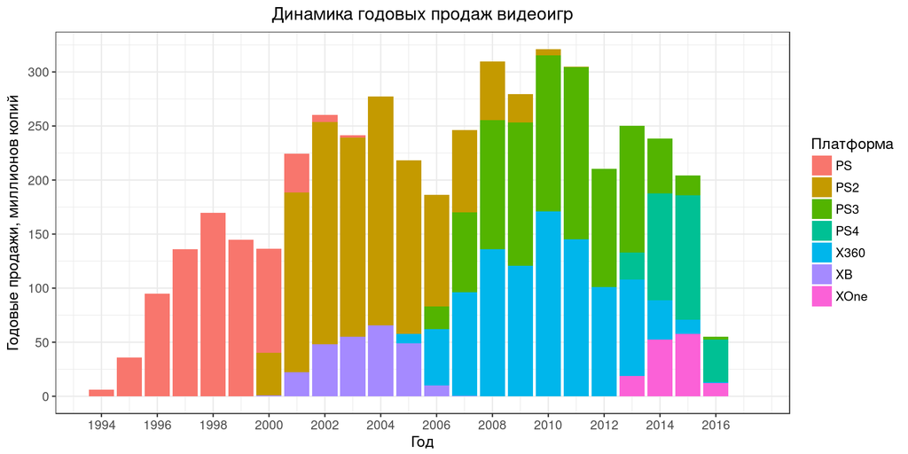

По приведенному графику можно заметить, что первая приставка линейки **PlayStation** не имела конкурента из линейки **XBox**. С выходом **PS2** в 2000-м году появляется первая **XBox**, но до следующего поколения приставок перевес продаж сохраняется в пользу **PlayStation**. С выходом следующего поколения (**PS3**, **XBox 360**) отличие в продажах кажется уже не таким существенным, но при появлении **PS4** и **XBox One** в 2013-м году по продажам снова начинает преобладать **PlayStation**.

### Динамика соотношения продаж

Проанализируем более строго динамику изменения соотношения продаж по семействам приставок. Для этого аггрегируем все продажи в пределах одного семейства в одну переменную и вычислим процентное соотношение в продажах между семействами относительно суммарного числа продаж. Получим таблицу следующего вида:

Динамика соотношения продаж

| Year | Platform | Total_Sales | Portion |
| --- | --- | --- | --- |
| 2000 | PS | 135.39 | 99.27409 |
| 2001 | PS | 201.95 | 90.07984 |
| 2002 | PS | 212.09 | 81.49785 |

Визуализируем данные:

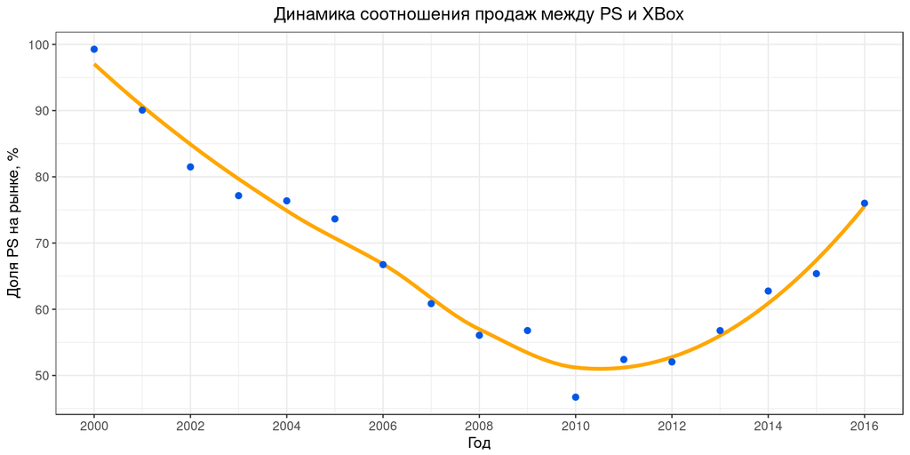

Данный график можно условно поделить на две части:

- Период с 2000-го по 2011-й год, когда с начала своего появления приставка **XBox** плавно перетягивала на себя долю рынка **PlayStation**, первоначально им монополизированную (в смысле противостояния **PS** - **XBox**)
- Период с 2012-го года по настоящее время, когда были анонсированы и впоследствии выпущены приставки последнего на данный момент поколения. В этом периоде **PlayStation** начинает восстанавливать позиции на рынке. Видимо, это можно объяснить тем, что последняя приставка **PlayStation** вышла крайне удачной по сравнению с конкурентом

### Соотношение продаж в группах семейство-поколение

Здесь мы более тщательно рассмотрим три поколения, для которых доступны данные: это **PS2**, **PS3** и **PS4** из семейства **PlayStation** и соответственно **XBox**, **XBox 360** и **XBox One** из семейства **XBox**. Для данного анализа введем переменную **Generation**, которая отвечает за условно первое (**PS2**, **XBox**), второе (**PS3**, **XBox 360**) и третье (**PS4**, **XBox One**) поколения приставок, а затем аггрегируем данные по продажам на пересечении семейств и поколений. Получим следующую таблицу сопряженности:

Распределение продаж по группам семейство-поколение

|  | PS | XBOX |
| --- | --- | --- |
| Первое | 1233.46 | 252.09 |
| Второе | 949.35 | 969.61 |
| Третье | 278.10 | 141.06 |

Визуализируем данные:

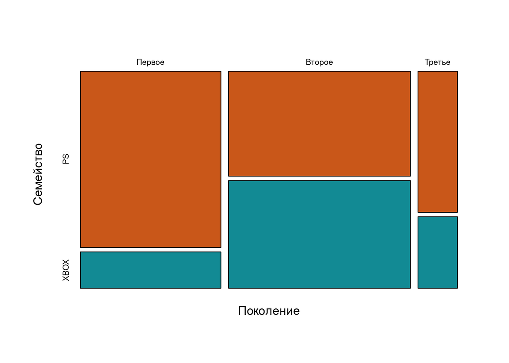

По данному графику хорошо видны тенденции изменения продаж при переходе от одного поколения к другому, а также между семействами приставок. В частности, как было сказано ранее, здесь отчетливо видно, что с выходом **XBox** второго поколения соотношение продаж почти сравнялось, но в третьем поколении пока преобладает **PlayStation**, хотя его жизненный цикл еще не окончен. В целом, по графику можно сделать вывод о том, что изначальная гипотеза подтвердилась, и соотношение между продажами в конкурирующих семействах приставок неравномерно и меняется с течением времени.

## Выводы

По результатам исследования можно сделать выводы о том, что соотношение сил на рынке конкурирующих приставок **PlayStation** и **XBox** неравномерно и меняется со временем, претерпевая переломные моменты при смене поколений.

[^1]: [Прямая ссылка](https://drive.google.com/file/d/0B_AraRsME-6teGFnOVpORVptZVU/view?usp=sharing) для скачивания данных